# QTM 151 - Using GitHub and Jupyter Notebooks

Forking repositories and writing text and code

Danilo Freire

danilo.freire@emory.edu

Emory University

05 September, 2024

# What is git and what is GitHub? 💻

## What is git?

- [git](https://git-scm.com/) is a version control system that allows you to track changes in your code
- It works similarly to Dropbox or Google Drive, but it is *way* more powerful
- For instance, you can go back to any version of your code, see who made changes, collaborate with others, and merge different versions into a single one
- git works in the command line, with graphical interfaces (e.g., [GitHub Desktop](https://desktop.github.com/)), and integrated into code editors (e.g., [VS Code](https://code.visualstudio.com/))
- git is a tool that you can use locally (only on your computer) or remotely (on a server like [GitHub](https://github.com)). If used online, it allows you to store your code in the cloud and collaborate with others (including yourself in the future!)
- git can track changes in any type of file, not only code
- In our case, we will use git to track changes in our Jupyter Notebooks too
- While git has several commands, you will only need to use a few of them
- The most common commands are `git clone`, `git add`, `git commit`, `git push`, and `git pull`. We will cover them in this lecture

[figure not shown]

## What is GitHub?

- [GitHub](https://github.com) is a website that hosts git repositories
- A repository is a folder that contains your code and its history
- GitHub allows you to share your code with others, collaborate, and contribute to other people’s projects
- In this course, you will use GitHub to submit your assignments and access the course materials
- GitHub offers many benefits to students, and you should consider using it for your projects and assignments even after this course
- Please create an educational account at [GitHub Education](https://education.github.com/) to access private repositories and [GitHub Copilot](https://copilot.github.com/), an AI pair programmer
- GitHub has a graphical interface that makes it easy to navigate and interact with repositories
- You can create repositories, branches, issues, pull requests, and more
- GitHub also offers a feature called [GitHub Pages](https://pages.github.com/), which allows you to create websites for free (such as this one!). But we will not cover it in this course
- Think of GitHub as a social network for code, where you can follow people, star repositories, and contribute to open-source projects

[figure not shown]

## Overview of a GitHub repository

[figure not shown]

## Overview of a GitHub repository

- Let’s take a closer look at our course’s repository
- The repository is located at https://github.com/danilofreire/qtm151
- You can see the files and folders in the repository, as well as when they were last modified
- You can also see other buttons, such as `Code`, `Issues`, `Pull requests`, `Actions`, `Projects`, `Wiki`, and `Security`. You don’t need to worry about them now
- If you click on `Clone`, you will get the URL to clone the repository to your computer. You can also download the repository as a ZIP file or open it in GitHub Desktop
- If you click on `Fork`, you will create a copy of the repository in your GitHub account. You can then make changes to the repository
- The `Star` button is used to bookmark the repository (think of a “like” button)

## GitHub Desktop

- [GitHub Desktop](https://desktop.github.com/) is a graphical interface for git
- It allows you to clone repositories, make changes, commit them, and push them to GitHub without using the command line
- You can also create branches, merge them, and resolve conflicts
- In our course, you will use GitHub Desktop to fork the course’s repository, update the course materials, and submit your assignments
- Let’s install GitHub Desktop and clone the course’s repository
- Please follow the instruction at https://github.com/apps/desktop

[figure not shown]

# Forking the course’s repository 🍴

## Forking the course’s repository

- To fork the course’s repository, go to https://github.com/danilofreire/qtm151
- Click on the `Fork` button in the top right corner (on the website!)
- You will be redirected to your GitHub account, where you will see a copy of the course’s repository. Click okay to continue
- This is important because [you will now have your own copy of the course’s materials](https://docs.github.com/en/get-started/quickstart/fork-a-repo)
- You can make changes to your copy without affecting the original repository
- Feel free to explore the repository and the files in it!

[figure not shown]

- If you have already forked it, great!
- You should see the same repository, but with your username instead of mine
- For instance: `https://github.com/your-username/qtm151`
- If you have that repository, you are ready to download it to your computer
- Please download your forked repository, not the original one!

## Downloading your forked repository with GitHub Desktop

- Open GitHub Desktop and click on “Clone a Repository from the Internet” (the second button)
- A window will open, then you click on “URL”
- You just need to type your username and the repository name (e.g., `your-username/qtm151`)
- Choose a local path to save the repository (a folder in your computer) and click on “Clone”
- *And that’s it!* Now you have the folder in your computer! :)

[figure not shown]

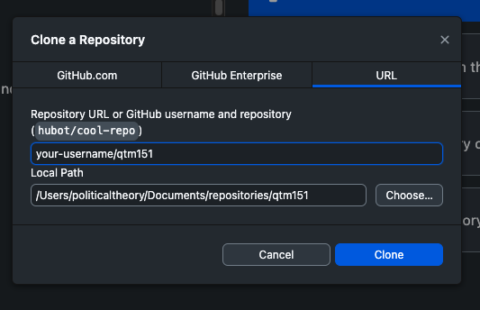

# How to make changes to your repository ✍️

## Add, commit, and push

### First, let’s add some text to the repository

- To make changes to your repository, you need to follow three steps: `add`, `commit`, and `push`
- `git add (file)` tells git to track changes in a file
- `git commit -m "message"` saves the changes in the file. You always need to write a message when you make changes, so you can remember what you did
- `git push` sends the changes to GitHub
- You can also use GitHub Desktop to do these steps without using the command line, but this is what is happening behind the scenes
- Let’s make a change to the repository and see how it works

[figure not shown]

- You will see a screen like this on GitHub Desktop
- You can either click on “Open the repository in your editor” or open the folder in your computer
- Then, you can make changes to the files in the folder (add code, remove lines, etc)

## Committing changes

- I have made some changes to the repository in my computer
- You can see the changes on GitHub Desktop. The lines in green are new lines, and the lines in red are removed lines
- Now we have to commit the changes
- Write a message in the little box at the bottom of the screen and click on “Commit to main”
- The message should be short and describe what you did

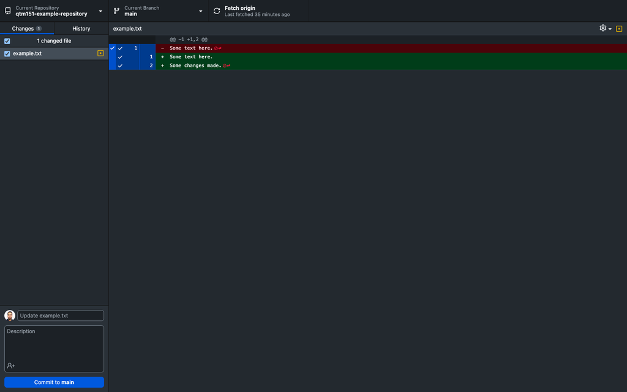

## Pushing changes to the repository

- After committing the changes, you need to push them to GitHub
- Click on “Push origin” to send the changes to your repository
- You will see a progress bar at the bottom of the screen
- Once the changes are pushed, you can see them on GitHub
- Just go to your repository on GitHub and check the files!
- You can also see the changes in the “History” tab on GitHub Desktop

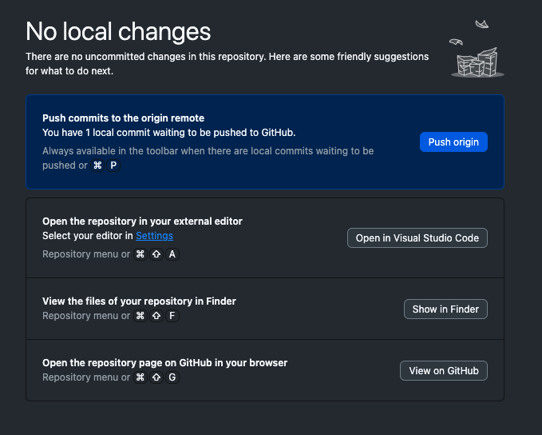

*And you’re done!* :)

# Updating the course’s repository 🔄

## Updating the course’s repository

### Pulling changes

- Now that you know how to make changes to your repository, it is time to learn how to download new content that I add to the course’s repository
- In git terms, `pull` or `fetch` are the commands that you use to update your local repository with new changes from the online repository
- You can do this easily on GitHub Desktop: just click on `Fetch origin`
- It will download the changes to your computer, and you can see them in the “History” tab
- That’s all there is to it!

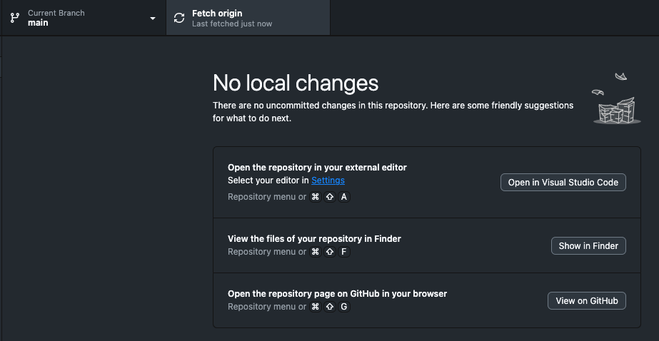

- Please remember to pull changes before you start working on your assignments :)

## Further readings

- If you want to learn more about git and GitHub, I recommend the following resources:
  - [GitHub Guides](https://guides.github.com/)
  - [Pro Git book](https://git-scm.com/book/en/v2)
  - [GitHub Desktop documentation](https://docs.github.com/en/desktop)
  - [GitHub Education](https://education.github.com/)
  - [GitHub Copilot](https://copilot.github.com/)
- There are also tons of tutorials on YouTube and other websites
  - GitHub has a nice [YouTube channel](https://www.youtube.com/github) with tutorials
  - Here is a [playlist for beginners](https://www.youtube.com/watch?v=r8jQ9hVA2qs&list=PL0lo9MOBetEFcp4SCWinBdpml9B2U25-f)
  - And here is a [playlist on GitHub Copilot](https://www.youtube.com/watch?v=JclDSHrSZV0&list=PL0lo9MOBetEHEHi9h0k_lPn0XZdEeYZDS)
  - This is a nice video about [how to use GitHub Desktop](https://www.youtube.com/watch?v=MaqVvXv6zrU&t=680s&pp=ygUOZ2l0aHViIGRlc2t0b3A%3D)

**Tip**

- Please have a look at these resources if you have the time
- And if you have any questions about git, GitHub, or GitHub Desktop, please let me know!

# Should we talk about Jupyter Notebooks? 🤓 📓

## What is a Jupyter Notebook?

- [Jupyter Notebook](https://jupyter.org/) is an open-source format that allows you to create documents with code, equations, visualisations, and text
- It is widely used in data science, machine learning, and scientific research
- Jupyter Notebooks can be used with many programming languages, such as Python, R, Julia, and Scala, but it is most commonly used with Python
- You can run code cells, see the output, and save the results in the same document
- They are a great example of [literate programming](https://en.wikipedia.org/wiki/Literate_programming), where you can explain your code and show the results in the same place
- And they are also intuitive and easy to use!

[figure not shown]

## How to install Jupyter

- If you [have already installed Anaconda](https://danilofreire.github.io/qtm151/tutorials/02-jupyter-markdown-tutorial.html), you have Jupyter on your computer
- You can also use Jupyter Notebooks online with [Google Colab](https://colab.research.google.com/)
- Although you can create a Jupyter Notebook on Anaconda, I recommend you to use a code editor like [VS Code](https://code.visualstudio.com/) to write your code
- If you want to run it from the command line, you can use the command `jupyter notebook` in the terminal
- More information about Jupyter Notebooks can be found [here](https://jupyter.org/), and a tutorial can be found [here](https://www.youtube.com/watch?v=WUeBzT43JyY)

[figure not shown]

# Writing text and code in Jupyter Notebooks ✍️ 💻

## Writing text in Jupyter Notebooks

- You can write text in Jupyter Notebooks using Markdown
- Markdown is a lightweight markup language that allows you to format text easily
- You can use headings, lists, links, images, tables, and more
- Please refer to [one of our tutorials](https://danilofreire.github.io/qtm151/tutorials/02-jupyter-markdown-tutorial.html#introduction-to-markdown) for more information on Markdown
- You can also use LaTeX to write equations in Jupyter Notebooks. More information can be found [here](https://jupyter-notebook.readthedocs.io/en/stable/examples/Notebook/Typesetting%20Equations.html)
- You can also include figures in Jupyter Notebooks using the following syntax: `![](path/to/figure.png)`
- Where `path/to/figure.png` is the directory and filename of the figure

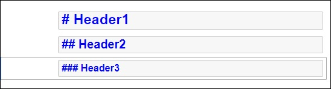

## Jupyter Markdown cheatsheet

[figure not shown]

## Writing code in Jupyter Notebooks

- You can write code in Jupyter Notebooks using code cells
- It is the same Python code that you would write in a `.py` file, but with the results displayed below the cell
- You can run the code cells by pressing `Shift + Enter` or clicking on the `Run` button
- You can also write comments in the code cells using the `#` symbol

[figure not shown]

## Connecting Jupyter with VS Code

- This is the tricky part: For Notebooks to compile, you have to connect Anaconda with VS Code and run the Notebook from there
- You can find more detailed instructions in our [tutorial](https://danilofreire.github.io/qtm151/tutorials/01-vscode-anaconda-tutorial.html#connecting-vs-code-with-anaconda), but I will show you the main steps here
- First, you need to install the [Python](https://marketplace.visualstudio.com/items?itemName=ms-python.python) and the [Jupyter](https://marketplace.visualstudio.com/items?itemName=ms-toolsai.jupyter) extensions in VS Code
- Then, you need to select the Python interpreter in the bottom left corner of the screen
- You have to select the `base` environment in Anaconda
- Finally, you can open a Jupyter Notebook in VS Code and run it from there :)

[figure not shown]

# Wrap-up 🚀

## Takeaways

- git and GitHub are great tools to store and share your code, and GitHub Desktop makes it easy to use them
- You can fork the course’s repository, make changes, and submit your assignments using git and GitHub
- Jupyter Notebooks allow you to easily write text and code in the same document, and it is one of the best tools for new programmers!
- As always, if you have any questions, please let me know!
- Drop me a message at danilo.freire@emory.edu if you need any help!

[GitHub and Jupyter](https://danilofreire.github.io/qtm151/lectures/lecture-02/02-github-jupyter.html)